# S1.5d: spazi vuoti dentro il tessuto simulato e taglia del nucleo dagli scarti veri: tornano i territori grandi e le cellule quasi senza citoplasma giuste?

geo_spatialtrans, report di step (protocollo v2)

Published

October 26, 2026

# In breve

**La domanda.** Se nel tessuto simulato mettiamo spazi vuoti (zone senza cellule, come i lumi e gli spazi fra le strutture), tornano la variabilità dei territori e i territori molto grandi che mancavano? E un modello della taglia del nucleo costruito sugli scarti veri risolve l’eccesso di cellule quasi senza citoplasma nel tumore del colon?

**Vuoti: sì per lo spazio vuoto e per i territori grandi, con un costo sui contatti.** Lo spazio vuoto torna in tutti e sei i tessuti (prima in tre). La quota di territori più grandi di tre volte il tipico torna in quattro tessuti (prima in nessuno). Nell’intestino la variabilità dei territori passa da 41 % sotto il vero a 2 % sopra. Le due controprove reggono: vuoti della stessa quantità ma troppo piccoli non fanno lo stesso effetto, e nel cuore, dove i vuoti veri sono pochi, la calibrazione non ne aggiunge. Il costo è che le cellule tolte dai vuoti si addensano altrove, e i nuclei a contatto superano il vero nel tumore del colon (69 % contro al più 57 %) e nello stroma (36 % contro al più 28 %). Inoltre i vuoti simulati sono macchie tondeggianti, mentre nell’intestino quelli veri sono lumi allungati fra i villi. Fra soli vuoti, sola densità variabile e le due cose insieme vincono i soli vuoti, ma per un verdetto (11 contro 10).

**Taglia: il difetto è capito, la correzione non vince.** Con i vuoti le cellule quasi senza citoplasma del tumore del colon salgono al 4.3 % (nelle cinque aree vere fra 1.5 e 2.9 %). Gli scarti veri, presi secondo la grandezza del territorio, le riportano al 2.2 %, ma la correzione perde altrettanti confronti su altre taglie: è parità, e per regola resta il modello di oggi. La controprova ha mostrato che pesa la dipendenza dal territorio, non la forma della coda come avevo scritto: nei territori piccoli il nucleo varia meno che nei grandi.

**Il predefinito non cambia.** La semina con i vuoti resta un’opzione: vince sulla disposizione (58 conferme contro 19) e perde sulla taglia (19 contro 21).

**Cosa ti chiedo di decidere** (deciso da Luca il 2026-10-26: le quattro proposte, DEC-023).

1. I test non hanno riconosciuto due degli undici errori inseriti apposta. Il codice di produzione è corretto: il revisore l’ha letto e due test nuovi lo verificano. Propongo di considerarlo un limite di potenza dei test, che non blocca lo step.
2. 1 076 cellule non sono state piazzate, in 5 simulazioni su 3 600, tutte in versioni che non hanno vinto (soprattutto il linfonodo con la densità molto variabile); i risultati non cambiano escludendole. Propongo di rinviarlo, senza blocco dello step.
3. Tre tolleranze erano scritte male prima del calcolo: gli scarti del gruppo della glia del cervello, che ha poche cellule; un test vecchio che fissava i valori precedenti; un confronto fra tabelle diverse. Propongo di trattarli come errori di pre-registrazione, come nello step precedente.
4. Nella semina uniforme, con la regola come scritta resta il modello di oggi (37 contro 36). Con la correzione indicata dal revisore vincerebbero gli scarti veri (39 contro 37), ma le cellule quasi senza citoplasma scenderebbero allo 0.7 %, sotto ogni area vera. Propongo di tenere il modello di oggi, come scritto.

# Decisioni e verifiche di Luca

- «Approvo così» (previsioni spaziali, intervalli, regole A e B, controprove; 2026-10-25)
- «Lo includiamo» (modello di taglia nel perimetro dello step; 2026-10-25)
- «Approvo così» (aggiunta sul modello di taglia: residui empirici, regola C, P-8c’, P-14, P-10’, CP-3; 2026-10-25)
- «Limite dei test, non blocca» (G-2 fallito come scritto, 9/11; 2026-10-26, DEC-023)
- «Limite noto, rinviato» (G-3 fallito come scritto, 1 076 cellule non piazzate; 2026-10-26, DEC-023)
- «Errori di pre-registrazione» (D-4, D-6, D-10; 2026-10-26, DEC-023)
- «Modello di oggi, come scritto» (regola C sulla semina uniforme; la sensibilità U3c resta riportata; 2026-10-26, DEC-023)
- «chiudi lo step» (lettura del riassunto «In breve», nessun dubbio nuovo, 2026-10-26). Step chiuso. Nota dell’agente: il riassunto aveva quattro decisioni invece di tre al massimo e non seguiva l’ordine delle sezioni del protocollo; Luca lo ha letto così e non ha chiesto di riscriverlo.
- Prossimo step scelto da Luca: S1.5e, semina eterogenea, parte 3 (vuoti che tolgono cellule; BL-162, BL-160, BL-164).

# Dubbi rinviati

| cosa | perché | cosa serve per chiuderlo | step destinatario | voce di BACKLOG |
| --- | --- | --- | --- | --- |
| i vuoti spostano le cellule invece di toglierle; vuoti tondeggianti invece che allungati | contatti sopra il vero nel tumore del colon (0.686 contro al più 0.567) e nello stroma (0.360 contro al più 0.283); eccesso di CV² a 50 µm smentito nel tumore del colon (0.055 contro almeno 0.103); ma… | vuoti che tolgono cellule (densità riferita all’area senza vuoti) e vuoti allungati; stessa prova | semina eterogenea, parte 3 | BL-162 |
| modello di taglia con dispersione che dipende dal territorio | cellule quasi senza citoplasma 0.0435 con i vuoti; residui empirici in parità (34 contro 34); intervallo a una coda | modello della dispersione che cresce col territorio, giudicato su un intervallo a due code [minimo, massimo] delle ROI vere | modello di taglia | BL-158 (aggiornata) |
| insiemi di nuclei diversi fra modello e riferimento nel linfonodo | 90° percentile dei residui 0.230 (StarDist di R3b) contro 0.250 (R6) | un solo insieme di nuclei per modello e intervalli | S1.6 (consolidamento) | BL-163 |
| saturazione della densità e ottimi al bordo della griglia | 1 066 cellule non piazzate nel linfonodo p2 seme 4 con la densità variabile (RD, RVD); vuoti dell’intestino 0.25, densità del linfonodo 0.9 con ℓ 80 µm, compartimenti s = 8 e ℓ = 1024 µm | griglie più ampie; limite della densità per regione | S1.6 o semina eterogenea, parte 3 | BL-164 |
| le quote costano due conferme | senza quote 60 contro 58; rifiuti dal 2.8 % all’11.0 % | decidere fra quote esatte e quote per regioni grandi | semina eterogenea, parte 3 | BL-160 (aggiornata) |
| regressioni che riscrivono file versionati | `test_S1.1.R` e `test_S1.2.R` riscrivono tempi in `results/S1.1`, `results/S1.2` (D-13) | scrivere i tempi nella cartella dei log | S1.6 | BL-165 |

# Cancelli e regole

Pre-registrazione: commit `c9dc20d`; ok di Luca il 2026-10-25 sulle previsioni spaziali e sull’aggiunta del modello di taglia (commit `f234bb2`). Banco al commit `830e90e`; test, braccio di sensibilità e controlli dopo la revisione al commit `2866cd6`. Il dettaglio dei cinque cancelli è nella sezione «Dopo il risultato».

Regola A: famiglia dell’eterogeneità (conferme in P-1, P-2, P-7, P-13)

| winner | RV | RD | RVD | counted |
| --- | --- | --- | --- | --- |
| RV | 11 | 10 | 10 | P-1, P-2, P-7, P-13 confermate (24 verdetti) |

Regola C: modello di taglia (gaussian = modello di oggi; empirical = residui empirici per decimo di territorio)

| base | emp | size_base | size_emp | spatial_base | spatial_emp | winner |
| --- | --- | --- | --- | --- | --- | --- |
| RV | W3 | 34 | 34 | 58 | 58 | gaussian |
| U | U3 | 37 | 36 | 19 | 18 | gaussian |

Sensibilità della regola C sulla semina uniforme con il decimo cercato sul territorio ricentrato (U3c, D-14; non sostituisce la regola)

| base | emp | size_base | size_emp | spatial_base | spatial_emp | winner |
| --- | --- | --- | --- | --- | --- | --- |
| U | U3c | 37 | 39 | 19 | 19 | empirical |

Regola B: predefinito dei preset

| final | reference | spatial_final | spatial_ref | size_final | size_ref | result |
| --- | --- | --- | --- | --- | --- | --- |
| RV | U | 58 | 19 | 19 | 21 | non adottata |

Conferme per previsione e braccio (spatial = P-1…P-7; size = P-8a, P-8b, P-8c; size_C = insieme della regola C)

| arm | P-1 | P-2 | P-3 | P-4 | P-5 | P-6 | P-7 | P-8a | P-8b | P-8c | P-10 | P-14 | P-9 | P-11 | P-12 | P-13 | spatial | size | size_C |
| --- | --- | --- | --- | --- | --- | --- | --- | --- | --- | --- | --- | --- | --- | --- | --- | --- | --- | --- | --- |
| U | 2 | 0 | 3 | 6 | 4 | 4 | 0 | 6 | 14 | 1 | 6 | 10 | 6 | 1 | 0 | 0 | 19 | 21 | 37 |
| N | 2 | 1 | 5 | 8 | 10 | 23 | 3 | 6 | 14 | 0 | 6 | 8 | 6 | 3 | 1 | 0 | 52 | 20 | 34 |
| R | 2 | 1 | 5 | 8 | 9 | 25 | 2 | 6 | 14 | 0 | 6 | 8 | 6 | 3 | 1 | 0 | 52 | 20 | 34 |
| RV | 2 | 2 | 5 | 10 | 9 | 27 | 3 | 6 | 13 | 0 | 6 | 9 | 6 | 6 | 2 | 4 | 58 | 19 | 34 |
| RD | 2 | 1 | 5 | 10 | 9 | 27 | 5 | 6 | 12 | 0 | 6 | 8 | 6 | 3 | 3 | 2 | 59 | 18 | 32 |
| RVD | 2 | 1 | 5 | 10 | 9 | 27 | 4 | 6 | 11 | 0 | 6 | 9 | 6 | 6 | 3 | 3 | 58 | 17 | 32 |
| VF | 2 | 1 | 5 | 9 | 9 | 27 | 1 | 6 | 14 | 0 | 6 | 8 | 6 | 2 | 1 | 0 | 54 | 20 | 34 |
| W3 | 2 | 2 | 5 | 10 | 9 | 27 | 3 | 6 | 13 | 1 | 6 | 8 | 6 | 6 | 2 | 4 | 58 | 20 | 34 |
| U3 | 1 | 0 | 3 | 6 | 4 | 4 | 0 | 6 | 14 | 1 | 6 | 9 | 6 | 1 | 0 | 0 | 18 | 21 | 36 |
| W3p | 2 | 2 | 4 | 10 | 9 | 27 | 3 | 6 | 15 | 0 | 6 | 8 | 6 | 6 | 2 | 4 | 57 | 21 | 35 |
| Q | 2 | 2 | 5 | 11 | 10 | 27 | 3 | 6 | 13 | 0 | 6 | 9 | 6 | 6 | 2 | 4 | 60 | 19 | 34 |
| U3c | 2 | 0 | 3 | 6 | 4 | 4 | 0 | 6 | 16 | 1 | 6 | 10 | 6 | 1 | 0 | 0 | 19 | 23 | 39 |

# Previsioni

Unità indipendente: ROI (valore della ROI = media dei 10 semi); stima = media delle 5 ROI ± 2 errori standard; contatti: seme. Bracci: U semina uniforme (predefinito); N compartimenti di S1.5c; R compartimenti ricalibrati; RV con i vuoti (vincente); RD con la densità variabile; RVD con entrambi; VF vuoti fini (controprova); W3, U3 residui empirici; W3p residui senza decimi (controprova); Q senza quote; U3c sensibilità.

Previsioni: stima ± 2 errori standard ed esito, quattro bracci (tutti i dodici in S1.5d_verdicts.csv)

| id | tessuto | unità | intervallo | RV (vincente) | esito | U | N | W3 |
| --- | --- | --- | --- | --- | --- | --- | --- | --- |
| P-1 | intestino di topo | tessuto | 0.366-0.65 | 0.569 ± 0.024 | confermata | 0.459 ± 0.018 confermata | 0.49 ± 0.022 confermata | 0.5742 ± 0.027 confermata |
| P-1 | tumore del colon | tessuto | 0.217-0.567 | 0.6857 ± 0.044 | smentita | 0.6184 ± 0.029 smentita | 0.5926 ± 0.056 indeterminata | 0.707 ± 0.043 smentita |
| P-1 | stroma del tumore | tessuto | 0.083-0.283 | 0.3595 ± 0.051 | smentita | 0.2653 ± 0.029 indeterminata | 0.3062 ± 0.047 indeterminata | 0.3722 ± 0.051 smentita |
| P-1 | linfonodo | tessuto | 0.35-0.75 | 0.8326 ± 0.019 | smentita | 0.8152 ± 0.028 smentita | 0.8185 ± 0.02 smentita | 0.832 ± 0.021 smentita |
| P-1 | cervello di topo | tessuto | 0-0.217 | 0.144 ± 0.016 | confermata | 0.1533 ± 0.031 confermata | 0.1665 ± 0.026 confermata | 0.1804 ± 0.017 confermata |
| P-1 | cuore | tessuto | 0-0.07 | 0.06979 ± 0.025 | indeterminata | 0.09537 ± 0.02 smentita | 0.0609 ± 0.014 indeterminata | 0.0662 ± 0.021 indeterminata |
| P-2 | intestino di topo | tessuto | -0.1-0.1 | 0.01675 ± 0.063 | confermata | -0.4156 ± 0.036 smentita | -0.4087 ± 0.037 smentita | 0.01675 ± 0.063 confermata |
| P-2 | tumore del colon | tessuto | -0.1-0.1 | -0.09926 ± 0.19 | indeterminata | -0.415 ± 0.11 smentita | -0.3623 ± 0.12 smentita | -0.09926 ± 0.19 indeterminata |
| P-2 | stroma del tumore | tessuto | -0.1-0.1 | -0.1402 ± 0.19 | indeterminata | -0.4348 ± 0.1 smentita | -0.2307 ± 0.14 indeterminata | -0.1402 ± 0.19 indeterminata |
| P-2 | linfonodo | tessuto | -0.1-0.1 | -0.09862 ± 0.23 | indeterminata | -0.4233 ± 0.13 smentita | -0.4191 ± 0.13 smentita | -0.09862 ± 0.23 indeterminata |
| P-2 | cervello di topo | tessuto | -0.1-0.1 | 0.03632 ± 0.16 | indeterminata | -0.2603 ± 0.093 smentita | -0.2134 ± 0.11 smentita | 0.03632 ± 0.16 indeterminata |
| P-2 | cuore | tessuto | -0.1-0.1 | -0.02604 ± 0.068 | confermata | -0.05608 ± 0.045 indeterminata | -0.03009 ± 0.062 confermata | -0.02604 ± 0.068 confermata |
| P-3 | intestino di topo | tessuto | 0.2165-0.2309 | 0.2121 ± 0.00087 | smentita | 0.1817 ± 0.00072 smentita | 0.1852 ± 0.00062 smentita | 0.225 ± 0.00094 confermata |
| P-3 | tumore del colon | tessuto | 0.3094-0.4334 | 0.3314 ± 0.0034 | confermata | 0.2958 ± 0.001 smentita | 0.3176 ± 0.0011 confermata | 0.3628 ± 0.0026 confermata |
| P-3 | stroma del tumore | tessuto | 0.1166-0.3371 | 0.1318 ± 0.0014 | confermata | 0.1071 ± 0.00032 smentita | 0.1277 ± 0.00058 confermata | 0.1331 ± 0.0018 confermata |
| P-3 | linfonodo | tessuto | 0.4491-0.5013 | 0.4729 ± 0.0017 | confermata | 0.4699 ± 0.00028 confermata | 0.4678 ± 0.00015 confermata | 0.4797 ± 0.0019 confermata |
| P-3 | cervello di topo | tessuto | 0.08208-0.1108 | 0.1054 ± 0.003 | confermata | 0.1064 ± 0.0022 confermata | 0.09983 ± 0.00091 confermata | 0.117 ± 0.003 smentita |
| P-3 | cuore | tessuto | 0.02354-0.03659 | 0.02603 ± 0.00043 | confermata | 0.02539 ± 0.0005 confermata | 0.0259 ± 0.00034 confermata | 0.02615 ± 0.00057 confermata |
| P-4 | intestino di topo | epiteliale | 0.2254-0.2452 | 0.2233 ± 0.001 | smentita | 0.1951 ± 0.00063 smentita | 0.1971 ± 0.00085 smentita | 0.2346 ± 0.001 confermata |
| P-4 | intestino di topo | stromale e muscolo liscio | 0.1489-0.186 | 0.1758 ± 0.001 | confermata | 0.1534 ± 0.001 confermata | 0.1492 ± 0.00096 indeterminata | 0.1906 ± 0.0012 smentita |
| P-4 | intestino di topo | immunitario | 0.2452-0.2586 | 0.2156 ± 0.0045 | smentita | 0.1528 ± 0.0019 smentita | 0.1816 ± 0.0019 smentita | 0.232 ± 0.0039 smentita |
| P-4 | tumore del colon | epiteliale | 0.3667-0.4795 | 0.3753 ± 0.0034 | confermata | 0.3135 ± 0.0012 smentita | 0.3587 ± 0.0017 smentita | 0.4183 ± 0.0029 confermata |
| P-4 | tumore del colon | fibroblasti | 0.1619-0.234 | 0.1965 ± 0.0032 | confermata | 0.2386 ± 0.00077 smentita | 0.1889 ± 0.0014 confermata | 0.2051 ± 0.0035 confermata |
| P-4 | stroma del tumore | epiteliale | 0.2963-0.491 | 0.2029 ± 0.0043 | smentita | 0.1019 ± 0.00065 smentita | 0.1906 ± 0.0025 smentita | 0.2183 ± 0.0054 smentita |
| P-4 | stroma del tumore | fibroblasti | 0.09584-0.1226 | 0.09604 ± 0.0013 | indeterminata | 0.1248 ± 0.001 smentita | 0.0937 ± 0.00096 smentita | 0.09342 ± 0.0013 smentita |
| P-4 | stroma del tumore | endoteliale | 0.1734-0.2035 | 0.1204 ± 0.00098 | smentita | 0.1136 ± 0.0014 smentita | 0.1242 ± 0.0018 smentita | 0.12 ± 0.0015 smentita |
| P-4 | stroma del tumore | immunitario | 0.1259-0.1555 | 0.09209 ± 0.0033 | smentita | 0.08941 ± 0.00077 smentita | 0.09271 ± 0.0027 smentita | 0.09416 ± 0.0034 smentita |
| P-4 | linfonodo | linfociti B | 0.4215-0.4854 | 0.4676 ± 0.0013 | confermata | 0.4831 ± 0.00044 confermata | 0.4623 ± 0.0005 confermata | 0.4742 ± 0.0017 confermata |
| P-4 | linfonodo | linfociti T | 0.4553-0.4986 | 0.4788 ± 0.0023 | confermata | 0.455 ± 0.00024 smentita | 0.4736 ± 0.00041 confermata | 0.4855 ± 0.0025 confermata |
| P-4 | cervello di topo | neuroni | 0.1002-0.161 | 0.1322 ± 0.0031 | confermata | 0.1359 ± 0.0038 confermata | 0.1222 ± 0.0022 confermata | 0.1407 ± 0.0044 confermata |

[output cut: 133 more lines]

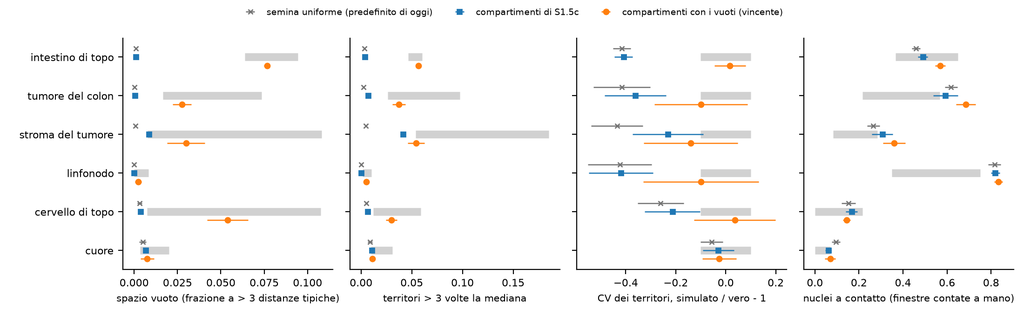

Misure di tessuto: spazio vuoto, territori più grandi di tre volte la mediana, variabilità dei territori, nuclei a contatto. Bande grigie: intervallo di rilevanza pre-registrato (minimo-massimo delle 5 ROI vere per spazio vuoto e territori grandi; ±0.10 per la variabilità, soglia di S1.3; conteggio manuale per i contatti). Punti: stima ± 2 errori standard (5 ROI, 10 semi ciascuna).

Cosa guardare: con i vuoti (arancione) spazio vuoto e territori grandi entrano nelle bande dove prima (quadrati blu) stavano a zero; la variabilità dei territori dell’intestino arriva a zero; i contatti di tumore del colon e stroma escono dalla banda a destra.

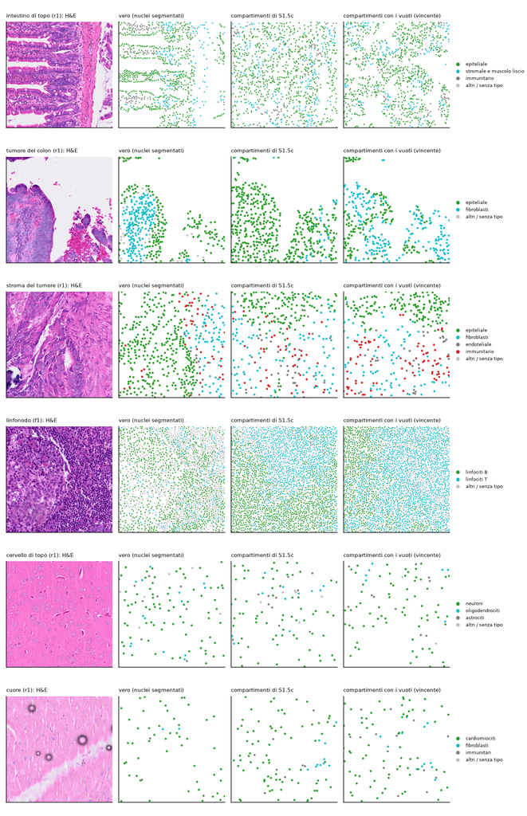

Un riquadro di 300 µm per tessuto (prima ROI, a 100 µm dall’angolo): H&E, nuclei veri con il tipo, compartimenti di S1.5c, compartimenti con i vuoti (seme 1).

Cosa guardare: i vuoti simulati sono macchie tondeggianti; nell’intestino i vuoti veri sono i lumi allungati fra i villi, che nessuna delle due semine riproduce.

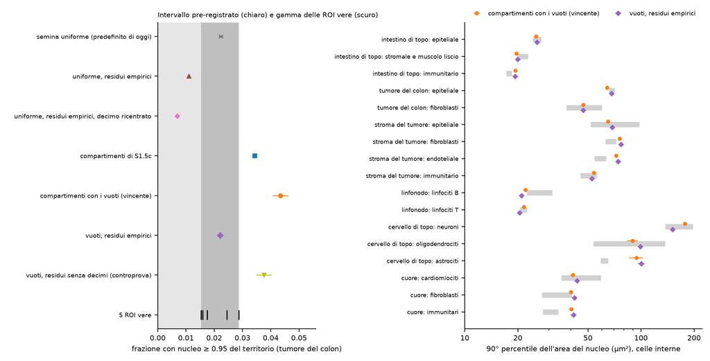

Taglia del nucleo. A sinistra: cellule quasi senza citoplasma nel tumore del colon per braccio, con l’intervallo pre-registrato (chiaro, a una coda) e la gamma delle 5 ROI vere (scuro, post hoc PH-4). A destra: 90° percentile dell’area del nucleo per tipo, intervallo fra ROI vere (grigio), modello di oggi e residui empirici.

# Dopo il risultato: cancelli, regole, controprove, post hoc e revisione avversariale

Scritto dopo il banco, le controprove, i cancelli ufficiali e la revisione avversariale. Ogni numero viene da un file di `results/S1.5d/` indicato accanto; il registro delle verifiche è `results/S1.5d/S1.5d_verification_log.csv`.

### Cancelli

| id | esito come scritto | dettaglio |
| --- | --- | --- |
| G-1 | **FAIL** (due errori di pre-registrazione dichiarati prima della corsa) | corsa ufficiale finale da un repository pulito, commit `2866cd6`: `test_S1.5d.R` 31/32, fallisce solo T13 (tolleranza che non tiene conto del numero di celle, D-6; T13b, il controllo cella per cella, … |
| G-2 | **FAIL** (9/11 mutanti pre-registrati rilevati nella corsa ufficiale) | non rilevati M3 (a_t senza i pesi dell’eterogeneità) e M5 (griglia di lambda_max non raffinata per ℓ_d). Il codice di produzione è corretto: lo ha letto il revisore del codice e lo verificano i test a… |
| G-3 | **FAIL** (1 076 cellule non piazzate, attese 0; md5 dei file letti 114/115) | su 3 600 unità (11 bracci + U3c): nessun ERROR in C2, C3, C5, C9; U = U di S1.5c 300/300 e N = N-a di S1.5c 300/300 (md5); rerun di 8 unità identico dopo le modifiche della revisione; superamenti di l… |
| G-4 | parte a 333/333; parte b 240/240; aggiunta: c1 **0/10 come scritta** (D-4), c2 10/10 | parte b con lo strumento corretto (D-11) e reso indipendente dal pacchetto dopo la revisione (RC-06): 240/240 (`S1.5d_G4_calcheck*.csv`). |
| G-5 | PASS | ricalcolo indipendente: 11 393 confronti, 0 discrepanze (1 794 verdetti, regole A, B, C, controprove, post hoc); revisione del codice: nessun errore che cambi i numeri del banco; quindici osservazioni… |

Correzione al testo pre-registrato (RC-02): il banco pre-registrato ha 2 400 unità (U, N, R, RV, RD, RVD, VF, Q) + 900 dell’aggiunta (W3, U3, W3p) = 3 300 unità, non «2 700» nella riga di G-3 né «600 unità» nell’aggiunta; con il braccio di sensibilità U3c (D-14) le unità sono 3 600.

### Previsioni (braccio RV; stima ± 2 errori standard)

| id | atteso | osservato | esito rispetto all’atteso |
| --- | --- | --- | --- |
| P-1 contatti | confermata in intestino e cervello; indeterminata in tumore del colon, stroma, cuore; smentita nel linfonodo | intestino 0.569 ± 0.024 confermata; cervello 0.144 ± 0.016 confermata; tumore del colon 0.686 ± 0.044 **smentita** (al più 0.567); stroma 0.360 ± 0.051 **smentita** (al più 0.283); cuore 0.070 ± 0.025… | peggio dell’atteso in tumore del colon e stroma (in S1.5c, N: indeterminate, 0.593 e 0.306) |
| P-2 variabilità dei territori | confermata in stroma e cuore; indeterminata in cervello, intestino, tumore del colon; smentita nel linfonodo | intestino +0.017 ± 0.063 **confermata** (N: -0.409); cuore -0.026 ± 0.068 confermata; tumore del colon -0.099 ± 0.187, stroma -0.140 ± 0.188, linfonodo -0.099 ± 0.231, cervello +0.036 ± 0.163 indeterm… | meglio dell’atteso in intestino e linfonodo, peggio nello stroma; gli errori standard fra ROI sono grandi (fino a 0.23) |
| P-3 nucleo/territorio del tessuto | 5/6, intestino smentita | 5/6, intestino 0.212 smentita (vero 0.217-0.231; N 0.185) | come atteso |
| P-4 per tipo | almeno 8/17 | 10/17 | come atteso |
| P-5 distanza dal vicino per tipo | almeno 10/17 | **9/17** (N 10, R 9) | uno sotto l’atteso; la perdita viene dalla ricalibrazione (R) |
| P-6 raggruppamento dei tipi | almeno 23/34 | 27/34 (N 23, R 25) | come atteso |
| P-7 numero di vicini | confermata in stroma, cervello, cuore; indeterminata in intestino e tumore del colon; smentita nel linfonodo | stroma, cervello, cuore confermate; intestino 0.294 e tumore del colon 0.285 **smentite** (vero 0.360-0.452 e 0.421-0.648); linfonodo smentita | peggio dell’atteso in intestino e tumore del colon (i vuoti alzano il valore da 0.256 e 0.255 di N, non abbastanza) |
| P-8a area mediana del nucleo | 6/6 | 6/6 | come atteso |
| P-8b per tipo | almeno 14/17 | **13/17** | uno sotto l’atteso |
| P-8c cellule quasi senza citoplasma | smentita | 0.0435 ± 0.0028, smentita (N 0.0343) | come atteso; i vuoti la peggiorano |
| P-9 eccentricità | 6/6 | 6/6 | come atteso |
| P-10 nuclei troncati | 6/6 | 6/6 | come atteso |
| P-11 spazio vuoto | 6/6 | **6/6** (N 3/6, U 1/6) | come atteso |
| P-12 eccesso di CV² a 50 µm | confermata in 5 (RV: intestino e cuore); linfonodo indeterminata | stroma e cuore confermate; intestino 0.0714 indeterminata (minimo vero 0.0721); cervello indeterminata; tumore del colon 0.055 e linfonodo -0.004 **smentite** | 2/6: i vuoti da soli non danno la variabilità della densità fra quadrati di 50 µm nel tumore del colon |
| P-13 territori sopra 3 volte la mediana | confermata in tumore del colon, stroma, cervello, cuore; indeterminata nell’intestino; smentita nel linfonodo | intestino 0.0564 confermata (N 0.0037); tumore del colon, linfonodo, cervello confermate; stroma 0.0544 indeterminata (minimo vero 0.0538); cuore indeterminata | 4/6 (N 0/6): la coda dei territori grandi torna |
| P-8c’ (W3, U3) | confermata in W3 e U3 | W3 0.0221 confermata; U3 0.0110 confermata (sotto la ROI vera più bassa, PH-4) | come atteso |
| P-14 90° percentile dell’area per tipo | almeno 11/17 in W3 e in RV; smentite attese in 5 tipi | RV **9/17**, W3 **8/17**; le 5 smentite attese ci sono tutte; in più smentite in RV: stromale e muscolo liscio dell’intestino, epitelio del tumore del colon, linfociti B (vedi PH-3) | sotto l’atteso in entrambi |
| P-10’ (W3) | 6/6, più bassa che con il modello gaussiano | 6/6; più bassa in 6 tessuti su 6 (per esempio tumore del colon 0.0160 contro 0.0367) | come atteso |

Conteggi per braccio in `S1.5d_counts.csv` (spaziali / taglie della regola B): U 19/21, N 52/20, R 52/20, RV 58/19, RD 59/18, RVD 58/17, VF 54/20, W3 58/20, U3 18/21, W3p 57/21, Q 60/19, U3c 19/23.

Cosa dicono le smentite (lette con le frasi scritte prima): **P-1 smentita** in tumore del colon e stroma, dove S1.5c era indeterminata: l’addensamento fuori dai vuoti porta troppi contatti. È la forma debole della smentita pre-registrata («dove S1.5c confermava») e indica la stessa cosa: i vuoti dovrebbero togliere cellule invece di spostarle. **P-11 confermata 6/6 e P-13 4/6**: la spiegazione di S1.5c (cellule al bordo degli spazi vuoti) regge. **P-5 e P-8b uno sotto l’atteso**: effetti di un verdetto, non sistematici.

### Controprove

- **CP-1, cuore: superata.** La calibrazione su tutte le ROI sceglie vuoti 0.025 e densità 0 (RV) (al più 0.025 e 0.3 richiesti); differenze appaiate RV - R: P-2 0.015 ± 0.020, P-7 0.005 ± 0.008, P-11 0.0006 ± 0.0037, P-13 0.0006 ± 0.0023, tutte compatibili con 0 (`S1.5d_cp.csv`).
- **CP-2, vuoti fini: superata.** VF conferma P-11 in 2 tessuti contro 6 di RV e P-13 in 0 contro 4; nell’intestino P-11 è smentita. La grandezza dei vuoti conta.
- **CP-3, residui senza decimi: fallita.** W3p dà 0.0375 di cellule quasi senza citoplasma (smentita), W3 0.0221; area mediana diversa da W3 in 5 tessuti su 6 e in 16 tipi su 17 (solo l’immunitario dell’intestino resta compatibile). Secondo la frase scritta prima, a contare è la dipendenza dei residui dal territorio, non la forma della coda: la spiegazione dell’esplorazione («la coda destra della lognormale è troppo pesante») cade. PH-2 lo conferma sui territori veri.

### Post hoc (dichiarati, dopo il banco)

- **PH-2, forma della coda o dipendenza dal territorio** (`S1.5d_posthoc_size_tail.csv`). Sui territori veri del gruppo dell’epitelio del tumore del colon: vero 0.0269, gaussiano 0.0704, residui empirici senza decimi 0.0640, con i decimi 0.0298. La dispersione dei residui cresce col territorio (0.38 nel primo decimo, 0.49 nel quinto, 0.61 nel decimo); senza decimi le celle piccole ricevono la dispersione delle grandi e il 77 % della coda in eccesso viene dai primi tre decimi.
- **PH-3, linfonodo e 90° percentile** (`S1.5d_posthoc_size_q90.csv`). 90° percentile dei residui: gaussiano 0.269, tabella dei nuclei di forma StarDist (R3b, su cui è stimato il preset, DEC-006) 0.230, nuclei di R6 (su cui sono gli intervalli di P-14) 0.250. Le smentite dei linfociti in P-14 vengono dalla differenza fra i due insiemi di nuclei, non dal modello.
- **PH-4, cellule quasi senza citoplasma per ROI vera** (`S1.5d_posthoc_p8c_real.csv`, `tools/S1.5d_posthoc_p8c.py`): tumore del colon 0.0175, 0.0154, 0.0159, 0.0287, 0.0245. U (0.0223) e W3 (0.0221) cadono nella gamma; U3 e U3c sotto; N, RV e gli altri bracci a compartimenti sopra.
- **Controllo della figura delle mappe.** Le coordinate dei nuclei veri e l’H&E coincidono: con (x, y) l’ematossilina nei punti dei nuclei è da 1.9 (linfonodo) a 11 volte (cervello) la media della ROI e il 100 % dei nuclei cade nella maschera; scambiando x e y torna alla media e i nuclei nella maschera scendono al 71-99.9 % (verifica fatta durante la stesura del report, nessun numero cambia).

### Revisione avversariale e come è stata chiusa

Due revisori indipendenti (profilo BIOSTAT_LEAD, commit `830e90e`). Ricalcolo: 0 discrepanze su 11 393 confronti. Codice: nessun errore che cambi i numeri del banco.

| voce | cosa | come è chiusa |
| --- | --- | --- |
| RC-01, RVC-1 | G-3 fallito (cellule non piazzate) non scritto nel file dello step | scritto sopra (G-3) con le 5 unità; verdetti invariati senza di esse |
| RC-02 | conteggi delle unità sbagliati nel testo pre-registrato | correzione sopra |
| RC-03 | nel braccio U3 il decimo dei residui si cerca sul territorio non ricentrato | braccio di sensibilità U3c (D-14), test T24; decisione a Luca |
| RC-04, RC-05 | T2 non usa il pacchetto; T18 controlla solo la frazione dei vuoti | aggiunti T2b e T18b |
| RC-06 | G-4 parte b circolare | strumento reso indipendente: 240/240 |
| RC-07…RC-10 | percorsi senza test (eterogeneità dei preset, inoltro di `resid_mode` e quote, regione tutta nei vuoti, fattore 1.1 di lambda_max) | test T19-T23 e mutanti M12-M20 |
| RC-11 | la documentazione di `place_cells()` non diceva che i compartimenti senza eterogeneità esplicita prendono i vuoti calibrati del preset | documentazione aggiornata |
| RC-12 | ottimi al bordo della griglia | D-desc-3 e rinvio |
| RC-13 | regressioni che scrivono nel repository | D-13; corsa finale da repository pulito |
| RC-14 | descrittiva non pre-registrata (D-desc-3b) | rinominata D-desc-7 e dichiarata non pre-registrata |
| RC-15 | base del confronto del codice | nessuna azione (informativa) |
| RVC-2 | la descrizione di una funzione dice «quadrati del tutto dentro la maschera», il codice usa la media ≥ 0.99 | 0/66 verdetti di P-12 cambiano con la variante stretta; resta la definizione dell’esplorazione |
| RVC-3 | 190 md5 condivisi fra bracci dove la calibrazione sceglie zero | atteso (stessi parametri, stesso seme) |
| RVC-4 | CP-3 fallita | confermato, sopra |
| RVC-5 | due file versionati modificati durante la revisione | ripristinati (D-13) |

# Cosa è girato

- Banco: 3 600 unità (30 ROI × 10 semi × 12 bracci), seme = 20261021 + 1000 · i + s come S1.5c; bracci pre-registrati generati al commit `830e90e`, U3c al commit `2866cd6`, su lesexp-server con 20-24 worker a un thread (temperatura del processore 68-78 °C).
- Calibrazioni: compartimenti per tipo (20 repliche, campi indipendenti per ROI) e vuoti e densità (6 300 + 3 470 semine, 0 errori), pieghe lascia-fuori-una-ROI.
- md5 dei 115 file letti prima e dopo: 114 identici; cambia solo `docs/BIO_REFERENCES.md` per le righe aggiunte da questo step.

Tempo mediano di place_cells() per unità (s)

| archetype | est.U | est.N | est.RV | est.W3 | est.Q |
| --- | --- | --- | --- | --- | --- |
| A1 | 29.4 | 41.1 | 41.2 | 40.4 | 41.9 |
| A2 | 16.9 | 19.1 | 19.8 | 20.0 | 19.5 |
| A3 | 3.1 | 14.7 | 7.2 | 7.6 | 7.1 |
| A4 | 30.8 | 33.5 | 39.1 | 34.7 | 35.4 |
| A5 | 16.7 | 25.6 | 23.8 | 22.7 | 23.7 |
| A6 | 7.6 | 13.8 | 10.4 | 10.3 | 10.3 |

# Appendice

## Esplorazione prima della pre-registrazione

Prima di scrivere questo file abbiamo guardato i nuclei veri (insieme di S1.5b e S1.5c) e le unità già simulate di S1.5c (bracci U e N-a, 10 semi), senza nessuna simulazione nuova[^explore][^realrefs]. Metriche: frazione dei pixel della maschera di tessuto valido lontani dal centro più vicino più di u volte la distanza mediana dal vicino (H_rel_u), CV² in eccesso dei conteggi in quadrati di 25, 50, 100 µm (0 per un processo di Poisson; non cambia se si tolgono centri a caso), CV della distanza dal vicino. Valori medi delle 5 ROI:

| tessuto | H_rel_3 vero | H_rel_3 S1.5c (N-a) | CV² in eccesso a 50 µm vero | idem S1.5c (N-a) | CV distanza dal vicino vero | idem S1.5c (N-a) |
| --- | --- | --- | --- | --- | --- | --- |
| intestino | 0.079 | 0.0011 | 0.085 | -0.005 | 0.33 | 0.37 |
| tumore del colon | 0.031 | 0.0006 | 0.220 | 0.007 | 0.32 | 0.33 |
| stroma | 0.035 | 0.0086 | 0.493 | 0.177 | 0.44 | 0.48 |
| linfonodo | 0.002 | 0.0000 | 0.023 | -0.011 | 0.20 | 0.12 |
| cervello | 0.054 | 0.0037 | 0.198 | -0.008 | 0.43 | 0.41 |
| cuore | 0.0095 | 0.0067 | 0.030 | 0.010 | 0.50 | 0.51 |

Altre due verifiche:

- **I vuoti non sono nuclei persi dal segmentatore.** Nelle 24 finestre contate a mano da Luca (R2b), H_rel_2 dei punti manuali contro i nuclei segmentati nella stessa finestra: intestino 0.136 contro 0.114, tumore del colon 0.022 contro 0.010, stroma 0.076 contro 0.053, linfonodo 0.001 contro 0.000, cervello 0.008 contro 0.010, cuore 0.026 contro 0.032 (`S1.5d_explore_manual.csv`). I punti manuali lasciano tanto spazio vuoto quanto i nuclei segmentati, o di più.
- **I vuoti sono tessuto acellulare.** Ematossilina media (deconvoluzione di colore) nei pixel a più di 3 distanze dal vicino contro i pixel sui centri dei nuclei: da 3.9 a 9.1 volte più bassa nei sei tessuti (intestino 0.0088 contro 0.0518); eosina bassa nell’intestino (0.017 contro 0.058: contenuto pallido dei lumi), invariata nello stroma (0.046 contro 0.051: matrice) (`S1.5d_explore_he.csv`).

Conseguenze per il disegno: (1) lo spazio vuoto manca nella simulazione in cinque tessuti e nel cuore no (il cuore diventa un controllo negativo); (2) la densità varia a 50-100 µm più del simulato anche dopo i tipi, soprattutto in tumore del colon, stroma e cervello; (3) nel linfonodo la differenza principale è un’altra: le distanze dal vicino simulate sono troppo regolari (CV 0.12 contro 0.18-0.22), effetto della distanza minima di 4 µm (BL-068), che S1.5d non cambia (DEC-009). Sul linfonodo quindi non ci aspettiamo che la variabilità dei territori torni.

## Pre-registrazione (testo del file dello step)

Commit dei cancelli e delle previsioni: `c9dc20d`. Ok di Luca su previsioni, intervalli, regole A e B e controprove: 2026-10-25, in chat, alla domanda «Approvi le previsioni con i loro intervalli, le due regole (quale eterogeneità vince, predefinito) e le due controprove come scritte sopra e nel file dello step?»: «Approvo così». Alla domanda sul perimetro («Il modello di taglia resta fuori da questo step, anche se probabilmente farà dire di no alla regola del predefinito?») Luca ha risposto «Lo includiamo»: l’aggiunta sul modello di taglia è nella sezione «Aggiunta: modello di taglia», con previsioni proprie: ok di Luca il 2026-10-25, in chat, alla domanda «Approvi l’aggiunta sul modello di taglia (scarti veri per grandezza del territorio, nessun tetto, regola di scelta, attese e controprova come scritte sopra e nel file dello step)?»: «Approvo così». Le previsioni già approvate non cambiano; P-8c e la regola B si leggono con la regola C come scritto nell’aggiunta.

### Cosa si implementa (scritto prima del codice)

**Eterogeneità della semina** in `R/04b2_seed_centroids.R`, solo con `spatial = "compartments"`: nuovo argomento `heterogeneity` (NULL predefinito: comportamento di S1.5c invariato, bit per bit, nessuna estrazione casuale in più) con `void_frac` φ_v, `void_ell_um` ℓ_v, `dens_sigma` σ_d, `dens_ell_um` ℓ_d; e `quotas` (TRUE predefinito, come S1.5c). Per ogni regione, dopo i campi dei tipi:

1. campo dei vuoti V(x) e campo della densità W(x), gaussiani a media 0 e varianza 1 con covarianza exp(-r² / (2 ℓ²)), 256 caratteristiche di Fourier casuali come i campi dei tipi, coordinate assolute; ciascuno estratto solo se attivo (φ_v > 0, σ_d > 0);
2. densità locale λ(x) = c · w_tipi(x) · exp(σ_d W(x)) · 1[V(x) ≤ τ], τ = Φ⁻¹(1 - φ_v): nessuna cellula dove V supera τ (frazione attesa dell’area = φ_v); c si fissa come oggi, quindi il numero di cellule della regione non cambia (le cellule si addensano nella parte non vuota);
3. a_t risolti sui punti della griglia fuori dai vuoti, con i pesi w_tipi · exp(σ_d W), così le frazioni attese restano quelle del preset; passo della griglia min(ℓ_tipi,min / 2, ℓ_d / 2, √(area / 4000)); lambda_max = 1.1 volte il massimo sulla griglia, superamenti contati;
4. se tutti i punti della griglia di una regione cadono in un vuoto, la regione resta senza vuoti (contato e riportato);
5. `quotas = FALSE` (solo per il braccio Q): nessun rifiuto per quota esaurita.

`tissue_preset_spec()` e `place_cells()`: tabella `heterogeneity` del preset (righe nuove di BIO_REFERENCES), `override_heterogeneity` per le pieghe del banco. Il predefinito del pacchetto resta la semina uniforme salvo la regola B.

**Ricalibrazione dei compartimenti per tipo** (BL-159, `tools/S1.5d_calibration_types.py`, da `tools/S1.5c_calibration.py`): stesso modello e stesso bersaglio (rapporto di connessione dei tipi principali nei bin 0-10-20-40-80-160 µm, etichette estratte sulle posizioni dei nuclei veri), con sei correzioni: campi indipendenti per ROI (seme che contiene l’indice della ROI); griglia ℓ ∈ {4, 8, …, 1024} µm e s ∈ {0, 0.5, …, 4, 5, 6, 7, 8}; composizione del preset (cervello: neuroni 0.700); focali = celle interne del tipo (al più 1 500) e frazione del tipo nella ROI, come la metrica di P-6; perdita sommata per ROI (non sulle coppie messe insieme); discesa per coordinate in tre giri, il primo su tutta la griglia con 5 repliche, il secondo e il terzo sui vicini (un passo in ℓ e in s) con 20 repliche. Pieghe lascia-fuori-un-ROI e tutte le ROI. Parametri al bordo della griglia: riportati.

**Calibrazione dei campi dei vuoti e della densità** (`tools/S1.5d_calibration_pos.R` con le metriche di `tools/S1.5d_metrics.py`): con il pacchetto stesso (`seed_centroids()`, senza tassellazione), sulle maschere delle 30 ROI, compartimenti ricalibrati della piega della ROI, distanza per nucleo e modello di taglia del gruppo (S1.5c, DEC-020), 2 repliche per punto (semi 20261025 + 1000 · i + r, diversi dal banco). Griglia: φ_v ∈ {0, 0.025, 0.05, 0.10, 0.15, 0.20}, ℓ_v ∈ {8, 16, 32, 64} µm, σ_d ∈ {0, 0.3, 0.6}, ℓ_d ∈ {10, 40} µm (105 combinazioni). Bersagli per ROI: H_rel a 1.5, 2, 3, 4; CV² in eccesso a 25, 50, 100 µm; CV della distanza dal vicino (centri ad almeno 10 µm dal bordo della maschera e 30 µm dal bordo del ROI, stessa regola per vero e simulato). Perdita della piega k: somma sulle ROI j ≠ k e sui bersagli di (simulato - vero)² / varianza fra le 5 ROI vere del bersaglio nel tessuto. Combinazioni con cellule non piazzate in una ROI: escluse per le pieghe che la usano. Tre famiglie scelte sulla stessa griglia: RV (σ_d = 0), RD (φ_v = 0), RVD (tutto). Se l’ottimo di tutte le ROI sta al bordo superiore di un parametro (o al bordo inferiore di una lunghezza), la griglia si estende una volta di un passo in quella direzione (ℓ × 2, φ_v + 0.05, σ_d + 0.3) per tutte le pieghe.

**Banco** `tools/S1.5d_bench.R`, come S1.5c: 30 ROI × 10 semi, maschera di tessuto valido di R2 a un solo cluster, seme = 20261021 + 1000 · i + s, parametri della piega lascia-fuori della ROI simulata; uscite in `/mnt/micron/geo_spatialtrans/S1.5d/`, un file per unità, rilanciabile, worker dal file `WORKERS` (fino a 20 col server libero, guardia termica come MMM); contatti con l’operatore di S1.4d e S1.5 sulle finestre di R2c. Bracci (2 700 unità):

| braccio | semina | compartimenti | vuoti | densità | ruolo |
| --- | --- | --- | --- | --- | --- |
| U | uniforme cieca al tipo (S1.5b) |  |  |  | riferimento del predefinito (= U di S1.5c, md5) |
| N | compartimenti (vincente di S1.5c) | S1.5c |  |  | riferimento (= N-a di S1.5c, md5) |
| R | compartimenti | ricalibrati |  |  | effetto della ricalibrazione |
| RV | compartimenti | ricalibrati | sì |  | candidato |
| RD | compartimenti | ricalibrati |  | sì | candidato |
| RVD | compartimenti | ricalibrati | sì | sì | candidato |
| VF | come RV, ℓ_v = 2 µm | ricalibrati | fini |  | controprova CP-2 |
| Q | vincente della regola A, `quotas = FALSE` | ricalibrati |  |  | sensibilità BL-160, generato dopo la regola A |

Tutti i bracci a compartimenti: distanza per nucleo e modello di taglia del gruppo (DEC-020).

**Metriche**: quelle di S1.5c (stesse funzioni) più `tools/S1.5d_metrics.py` (H_rel_u, CV² in eccesso, CV della distanza dal vicino, frazione dei territori sopra 3 volte la mediana), celle interne con la regola di R3, stesse funzioni per vero e simulato.

### Scelte decise dai dati (regole scritte prima del banco)

- **Regola A, famiglia dell’eterogeneità.** Fra RV, RD, RVD vince quella con più conferme in P-1, P-2, P-7 e P-13 (24 verdetti; nessuno è un bersaglio della calibrazione); a parità vince quella con meno parametri; fra RV e RD a parità, RV (è il meccanismo indicato dall’analisi di S1.5c). La tabella `heterogeneity` dei preset viene dalla famiglia vincente (calibrazione su tutte le ROI).
- **Regola B, predefinito dei preset** (la regola 3 di S1.5c, invariata): la semina a compartimenti con l’eterogeneità vincente diventa il predefinito se, rispetto a U, conferma più previsioni nell’insieme spaziale (P-1…P-7) **e** almeno altrettante nell’insieme delle taglie (P-8). Altrimenti resta un’opzione. Avviso scritto prima: P-8c (cellule quasi senza citoplasma nel tumore del colon) dipende dal modello di taglia (BL-158), che S1.5d non tocca; in S1.5c è stata la sola ragione del «no» e probabilmente lo sarà ancora.
- **Ricalibrazione dei compartimenti** (BL-159): correzione di difetti dichiarati, adottata per costruzione; il braccio N serve a misurarne l’effetto. Se R conferma meno previsioni per tipo (P-4, P-5, P-6) di N, è un dubbio dello step.

Le previsioni si giudicano sul braccio vincente della regola A; gli altri si riportano accanto.

### Cancelli (al massimo 5)

| id | controllo | tolleranza | comando |
| --- | --- | --- | --- |
| G-1 | **batteria di test** `R/testing/test_S1.5d.R`: nessun centro dove V supera τ; frazione dei vuoti sulla griglia = φ_v entro 3 errori Monte Carlo su 200 campi; con un campo della densità, rapporto delle… | tutte PASS salvo i due FAIL noti | `bash R/testing/run_S1.5d.sh test` |
| G-2 | **mutanti** (copie del codice): M1 vuoti ignorati all’accettazione; M2 τ = Φ⁻¹(φ_v); M3 a_t senza i pesi dell’eterogeneità; M4 frequenze del campo della densità con scala ℓ invece di 1/ℓ; M5 griglia d… | 8/8 rilevati | `bash R/testing/run_S1.5d.sh mutants` |
| G-3 | **invarianti, riproducibilità, compatibilità** sulle 2 700 unità: C2, C3, C5, C9 senza ERROR; 0 cellule non piazzate; U = U di S1.5c e N = N-a di S1.5c (md5, 300/300 ciascuno); rerun di 8 unità identi… | 0 ERROR, 0 non piazzate, 300/300 + 300/300, 8/8, md5 invariati | `Rscript --vanilla tools/S1.5d_bench.R check` |
| G-4 | **calibrazione dei tipi rifatta in R**: le etichette del pacchetto sulle posizioni dei nuclei veri con i parametri di tutte le ROI riproducono le curve di Python, entrambe con 20 repliche; il banco le… | z = Δ log R / errore standard della differenza (dalle repliche): \|z\| ≤ 4 in tutti i bin con almeno 200 coppie reali dello stesso tipo; 30/30 e 30/30 | `Rscript --vanilla tools/S1.5d_calcheck.R` |
| G-5 | **ricalcolo indipendente** della revisione avversariale: due revisori ricalcolano P-1…P-13, CP-1, CP-2, le regole A e B dal codice e dai dati | identico o ≤ 1e-9 | revisione |

### Previsioni

Unità indipendente: **ROI** (5 per tessuto; valore della ROI = media dei 10 semi; stima = media delle 5 ROI ± 2 errori standard, errore standard = deviazione standard fra ROI / √5), appaiata al vero della stessa ROI dove la previsione lo dice; **seme** per P-1 (finestre fisse), come S1.5c. Nessun bootstrap. Intervalli «fra ROI vere» = [minimo, massimo] delle 5 ROI vere, calcolati prima di ogni simulazione nuova[^realrefs]. Gli attesi sono stime a mano per il braccio RVD (RV fra parentesi dove diverso).

| id | quantità | tessuto | atteso | intervallo di rilevanza | fonte | 2 errori standard tipici |
| --- | --- | --- | --- | --- | --- | --- |
| P-1 | frazione di nuclei a contatto, finestre di R2c | intestino / tumore del colon / stroma / linfonodo / cervello / cuore | le cellule si addensano fuori dai vuoti, i contatti salgono un poco: confermata in intestino e cervello; indeterminata in tumore del colon, stroma, cuore; **smentita nel linfonodo** (i contatti lì ven… | 0.366-0.650 / 0.217-0.567 / 0.083-0.283 / 0.350-0.750 / 0.000-0.217 / 0.000-0.070 | B-127…B-132 (manuale, due stadi), come S1.5c | ≈ 0.03-0.05 |
| P-2 | CV dell’area dei territori, simulato / vero - 1, appaiato per ROI | 6 tessuti | sale verso 0: confermata in stroma e cuore; indeterminata in cervello e, con la densità, in intestino e tumore del colon (con i soli vuoti circa -0.15: smentita ma più vicina); **smentita nel linfonod… | -0.10…+0.10 | soglia di S1.3 (B-2), approvata da Luca il 2026-10-08 | 0.04-0.13 |
| P-3 | rapporto mediano nucleo/territorio del tessuto, celle interne | 6 tessuti | come S1.5c: confermata 5/6, intestino smentita | come S1.5c | P-2 di S1.5 | < 0.005 |
| P-4 | rapporto mediano nucleo/territorio per tipo | 17 tipi | almeno 8 confermati (S1.5c: 8) | fra ROI vere per tipo | P-7 di S1.5b | < 0.005 |
| P-5 | distanza relativa dal vicino per tipo | 17 tipi | almeno 10 confermati (S1.5c: 10); indeterminata per costruzione dove l’intervallo è più stretto di 2 errori standard (epitelio dell’intestino, linfociti B e T) | fra ROI vere per tipo | `S1.5c_real_intervals.csv` | ≈ 0.01-0.03 |
| P-6 | rapporto di connessione dei tipi a 10-20 e 40-80 µm | 17 tipi × 2 | almeno 23 confermati su 34 (S1.5c: 23); la ricalibrazione può alzarli | fra ROI vere | `S1.5c_real_intervals.csv` | 0.05-0.3 |
| P-7 | CV del numero di vicini entro 4 distanze mediane dal vicino | 6 tessuti | confermata in stroma, cervello, cuore (come S1.5c); indeterminata in intestino e tumore del colon (i vuoti la alzano); smentita nel linfonodo | 0.360-0.452 / 0.421-0.648 / 0.461-0.791 / 0.141-0.241 / 0.291-0.682 / 0.309-0.375 | fra ROI vere (`S1.5c_real_intervals.csv`) | ≈ 0.01-0.03 |
| P-8a | area mediana del nucleo (regressione) | 6 tessuti | confermata 6/6 | intervalli di P-1 di S1.5b | P-1 di S1.5b | come S1.5c |
| P-8b | area mediana del nucleo per tipo (regressione) | 17 tipi | almeno 14 confermati (astrociti smentita, attesa) | intervalli di P-2 di S1.5b | P-2 di S1.5b | come S1.5c |
| P-8c | cellule quasi senza citoplasma (nucleo ≥ 0.95 del territorio) | tumore del colon | **smentita** (BL-158, fuori dallo step; l’addensamento fuori dai vuoti la peggiora) | 0-0.0287 | P-5 di S1.5b | ≈ 0.002 |
| P-9 | eccentricità mediana del territorio, simulato - vero | 6 tessuti | confermata 6/6 (i territori al bordo dei vuoti si allungano poco rispetto alla mediana) | -0.05…+0.05 | soglia di S1.3 (B-4) | ≈ 0.01 |
| P-10 | frazione di nuclei troncati dal tetto φ | 6 tessuti | confermata 6/6 | 0-0.05 | criterio di Luca (S1.4) | ≈ 0.003 |
| P-11 | spazio vuoto H_rel_3 (bersaglio della calibrazione, piega lascia-fuori) | 6 tessuti | confermata 6/6 | 0.0638-0.0943 / 0.0165-0.0735 / 0.0076-0.1082 / 0-0.0082 / 0.0075-0.1076 / 0.0034-0.0200 | fra ROI vere (`S1.5d_real_intervals.csv`) | 0.002-0.01 |
| P-12 | CV² in eccesso a 50 µm (bersaglio, piega lascia-fuori) | 6 tessuti | confermata in 5 (RV: in intestino e cuore); linfonodo indeterminata | 0.0721-0.1128 / 0.1029-0.3842 / 0.1942-1.073 / 0.0024-0.0457 / 0.0534-0.4234 / -0.0140-0.1305 | fra ROI vere | 0.005-0.05 |
| P-13 | frazione dei territori sopra 3 volte la mediana (non è un bersaglio) | 6 tessuti | confermata in tumore del colon, stroma, cervello, cuore; indeterminata nell’intestino (intervallo stretto); smentita nel linfonodo | 0.0463-0.0604 / 0.0263-0.0976 / 0.0538-0.185 / 0.0013-0.0103 / 0.0123-0.0588 / 0.0098-0.0307 | fra ROI vere (`S1.5d_real_intervals.csv`; uguale a PH-1 di S1.5c) | 0.002-0.008 |

Cosa direbbe una smentita.

- **P-13 e P-2 smentite** in intestino, tumore del colon o stroma, con P-11 confermata: lo spazio vuoto è giusto ma non dà la coda dei territori grandi; la spiegazione di S1.5c (cellule al bordo dei vuoti) sarebbe sbagliata o incompleta (forma dei vuoti: lumi allungati e anelli di cellule, che un campo gaussiano non produce).
- **P-11 smentita**: la calibrazione non si trasferisce fra ROI (i vuoti dipendono dalla ROI più che dal tessuto).
- **P-1 smentita** dove S1.5c confermava: l’addensamento fuori dai vuoti porta troppi contatti; i vuoti dovrebbero togliere cellule invece di spostarle (cioè la densità manuale non andrebbe riferita all’area con i vuoti).
- **P-4, P-5, P-6 peggiori di S1.5c**: la ricalibrazione o l’eterogeneità rompono le misure per tipo.

### Controprova

- **CP-1, controllo negativo nel cuore.** Lì lo spazio vuoto simulato è già quello vero (0.0067 contro 0.0095). La calibrazione di tutte le ROI del cuore deve scegliere φ_v ≤ 0.025 e σ_d ≤ 0.3, e nel braccio vincente P-2, P-7, P-11 e P-13 del cuore devono restare entro 2 errori standard da R. Se la calibrazione mettesse vuoti dove i dati non li mostrano, starebbe adattando il rumore.
- **CP-2, vuoti della taglia sbagliata (braccio VF).** Stessa frazione dei vuoti di RV, lunghezza di correlazione 2 µm (più piccola della distanza fra nuclei): toglie posti senza creare spazi grandi. Deve confermare P-11 e P-13 in meno tessuti di RV, in particolare smentire P-11 nell’intestino. Se VF facesse altrettanto bene, la grandezza dei vuoti non conterebbe e la spiegazione degli spazi vuoti cadrebbe.

### Aggiunta: modello di taglia (scritta dopo l’ok sulle previsioni spaziali, prima di ogni calcolo)

**Dubbio ricevuto: BL-158.** Con i compartimenti le cellule quasi senza citoplasma del tumore del colon salgono al 3.4 % (vero al più 2.9 %). In S1.5c è stata la sola ragione del «no» della regola del predefinito.

**Esplorazione dichiarata** (solo nuclei e territori veri, nessuna simulazione; `tools/S1.5d_explore_size.py`, `S1.5d_explore_sizeform.py`, `S1.5d_size_refs.py`, `S1.5d_size_emp.py`; uscite `results/S1.5d/S1.5d_explore_size_real.csv`, `S1.5d_explore_sizeform.csv`, `S1.5d_size_groups.csv`, `S1.5d_size_check.csv`, `S1.5d_size_resid.csv`, `S1.5d_size_check_m3.csv`, `S1.5d_real_q90.csv`). Tre modelli valutati sui territori veri, parametri stimati su 4 ROI e valutati sulla quinta:

| epitelio del tumore del colon (media delle 5 pieghe) | vero | M0, attuale (lognormale, dispersione costante del gruppo) | M1 (dispersione che dipende dal territorio, per gruppo) | M3 (residui empirici del gruppo per decimo di log A_T) |
| --- | --- | --- | --- | --- |
| frazione con nucleo ≥ 0.95 del territorio | 0.0264 | 0.0687 | 0.0581 | 0.0293 |
| area mediana del nucleo (µm²) | 32.65 | 32.57 | 31.48 | 32.65 |
| 90° percentile dell’area (µm²) | 68.09 | 67.80 | 69.58 | 68.42 |

Cosa mostrano: (1) con i territori veri, M0 prevede 2.6 volte la coda vera; più i territori simulati diventano giusti, più P-8c peggiora (semina uniforme 2.2 %, compartimenti 3.4 %); (2) i residui veri sono asimmetrici a sinistra in 8 gruppi su 10 (positivi solo nel gruppo immunitario e stromale dell’intestino, +0.13, e nel cuore, +0.09) (tumore del colon, epitelio: asimmetria -0.45, 99° percentile standardizzato 2.10 contro 2.33 della gaussiana): la coda destra della lognormale è troppo pesante; (3) la dispersione che cresce col territorio (pendenza del logaritmo della dispersione 0.267 nel gruppo dell’epitelio del tumore del colon) spiega solo un quarto dell’eccesso; (4) un tetto sotto 1 non ha appoggio nei dati: nel tumore del colon il 99° percentile del rapporto vero è 1.05 (B-122), quindi resta DEC-005 (nessun tetto); (5) il modello diretto del rapporto (logit, stimato per tipo in `S1.5d_explore_sizeform.csv`) accorcia troppo la coda (0.0150) e allarga le taglie grandi (90° percentile 79.9): scartato. Candidati per il banco: M0 e M3. M1 non entra (effetto piccolo, un parametro in più).

**Cosa si implementa.** In `R/04b4_derive_cell_geometry.R`: colonna opzionale del catalogo `nucleus_area_resid` (nome di una tabella di residui); se assente o NA, comportamento attuale bit per bit. Con la tabella: log A_N bersaglio = media del modello del gruppo (come oggi, stessi ρ_g, β_g, conversione «preserve_area») + r, con r estratto per interpolazione lineare dei 101 quantili (0, 0.01, …, 1) dei residui veri del gruppo nel decimo di log A_T della cella; decimi definiti sui territori veri del gruppo (log A_T assoluto, coerente con «preserve_area»); celle fuori dall’intervallo vero nel decimo estremo; un’uniforme per cella (stesso numero di estrazioni di oggi, quindi le posizioni non cambiano). Tabelle in `inst/extdata/size_resid_<preset>.csv` (generate da `tools/S1.5d_size_resid_table.py` dai residui del modello del gruppo di S1.5b, tutte le 5 ROI, come il modello di taglia di S1.5b), con una riga per gruppo in BIO_REFERENCES (fonte e md5 della tabella). I residui contengono l’errore di segmentazione, come σ oggi (B-093).

**Bracci aggiunti al banco** (600 unità; totale 3 300 più Q): **W3** = vincente della regola A con M3; **U3** = semina uniforme con M3 (modello ricentrato, come U). Q usa il modello di taglia vincente della regola C.

**Regola C, modello di taglia** (prima della regola B). Sul vincente della regola A: M3 vince se conferma più previsioni di M0 nell’insieme delle taglie (P-8a, P-8b, P-8c, P-10, P-14: 6 + 17 + 1 + 6 + 17 = 47) e non meno nell’insieme spaziale (P-1…P-7); a parità vince M0 (nessuna ipotesi in più). Stessa regola fra U3 e U per la semina uniforme. Le previsioni P-8 e P-14 si giudicano sul vincente delle regole A e C; gli altri bracci accanto.

**Regola B** (approvata) si applica al vincente delle regole A e C contro il predefinito di oggi: U se la regola C sulla semina uniforme dà M0, U3 se dà M3 (in quel caso M3 entra comunque nel predefinito uniforme).

**Previsioni aggiunte** (unità ROI, media dei 10 semi, stima = media dei 5 ROI ± 2 errori standard, come le altre; attesi per W3):

| id | quantità | tessuto | atteso | intervallo di rilevanza | fonte | 2 errori standard tipici |
| --- | --- | --- | --- | --- | --- | --- |
| P-8c’ | cellule quasi senza citoplasma, W3 e U3 | tumore del colon | **confermata** in W3 e U3 (sui territori veri M3 dà 0.029; i territori simulati dell’epitelio sono più grandi dei veri) | 0-0.0287 | P-5 di S1.5b (come P-8c) | ≈ 0.002 |
| P-14 | 90° percentile dell’area del nucleo per tipo, celle interne | 17 tipi | almeno 11 confermati su 17 in W3 e in M0 (sui territori veri M3 ne conferma 12); **smentita attesa** negli astrociti (gruppo con microglia e oligodendrociti: 86-99 contro 59-65), nelle endoteliali del… | [min, max] fra ROI vere | `S1.5d_real_q90.csv` | ≈ 1-5 µm² |
| P-10’ | frazione di nuclei troncati, W3 | 6 tessuti | confermata 6/6, più bassa di M0 nei tessuti densi | 0-0.05 | come P-10 | ≈ 0.003 |

Cosa direbbe una smentita: **P-8c’ smentita** con M3: la coda nel simulato non viene dalla forma dei residui ma dai territori simulati (forma o taglia dei territori dell’epitelio), e il difetto va cercato nella semina; **P-14 peggiore con M3 che con M0** in molti tipi: i residui empirici del gruppo trasferiscono a un tipo la coda di un altro tipo dello stesso gruppo.

**Controprova CP-3 (residui permutati).** Braccio W3p, 300 unità: stessi residui empirici ma estratti senza tener conto del decimo di territorio. Toglie la dipendenza dal territorio e lascia la forma della distribuzione. Attesa: P-8c’ ancora confermata (perché a contare è la forma della coda) e P-8a, P-8b uguali a W3 entro 2 errori standard. Se W3p smentisse P-8c’ mentre W3 la conferma, a contare sarebbe la dipendenza dal territorio, non la forma della coda, e la spiegazione dell’esplorazione cadrebbe.

**Cancelli**: G-1 aggiunge: con la tabella dei residui, quantili simulati sulla griglia dei territori veri entro 0.02 (distanza di Kolmogorov) dai residui veri, per gruppo e decimo; senza tabella identico bit per bit; celle fuori intervallo assegnate al decimo estremo. G-2 aggiunge M9 (decimo calcolato su log A_T relativo invece che assoluto), M10 (tabella di un altro gruppo), M11 (tabella ignorata: lognormale): 11/11. G-3 copre 3 600 unità (U3, W3, W3p in più; Q). G-4 aggiunge: le tabelle del pacchetto riproducono i quantili di `tools/S1.5d_size_emp.py` (≤ 1e-9).

**Tempi**: 3 600 unità; da S1.5c (1 800 unità in 248.7 min con 3 worker, cioè circa 0.41 minuti-worker per unità) circa 1 500 minuti-worker, circa 75-90 minuti con 20 worker, più le calibrazioni (circa 1.5 ore). Totale circa 3-3.5 ore.

### Note di sviluppo (scritte prima delle calibrazioni, dei cancelli ufficiali e del banco; non cambiano previsioni né intervalli)

- **D-1, insieme di nuclei delle tabelle dei residui nel linfonodo e nel cuore.** Il modello di taglia di quei due preset non è stimato sui nuclei di R6 ma sui nuclei di forma StarDist della maschera unica di R3b (DEC-006; dispersione 0.210 nel linfonodo contro 0.295 dei nuclei di R6). I residui si calcolano quindi rispetto al modello del preset sullo stesso insieme su cui è stimato (`tools/S1.5d_export_r3b_cells.R`, celle interne, nuclei di forma StarDist, tutte le 5 ROI: 99 684 celle nel linfonodo, 2 367 nel cuore). Negli altri quattro tessuti i residui sono quelli dei nuclei di R6, coerenti con il modello del gruppo alla sesta cifra (`results/S1.5d/S1.5d_size_resid_check.csv`). L’esplorazione e gli intervalli di P-14 restano sui nuclei di R6, come P-8b.
- **D-2, tolleranza del controllo della media dei residui.** Il generatore delle tabelle controlla che la media dei residui sia vicina a 0: 1e-3 nella prima versione, 1e-2 ora. Nel cuore la media vale -0.0039 perché i parametri del preset sono arrotondati a tre cifre (ρ 0.154 invece di 0.153693: 2 log(0.154 / 0.153693) = 0.0040). I residui sono rispetto alla media che il pacchetto usa davvero, quindi lo spostamento è corretto che resti.
- **D-3, invarianza dello spazio vuoto relativo.** La descrizione di `tools/S1.5d_metrics.py` diceva che H_rel non cambia se si tolgono centri a caso: è vero solo per un processo di Poisson. È esattamente invariante il CV² in eccesso. Corretto il commento; le definizioni non cambiano. Conseguenza dichiarata: H_rel e la CV della distanza dal vicino (bersagli della calibrazione) risentono dei nuclei che il segmentatore perde; nelle finestre contate a mano lo spazio vuoto dei punti manuali è pari o più alto di quello dei nuclei segmentati (esplorazione).
- **D-4, errore di pre-registrazione nel cancello G-4 (aggiunta).** La clausola «le tabelle del pacchetto riproducono i quantili di `tools/S1.5d_size_emp.py` (≤ 1e-9)» confronta quantità diverse: quello script calcola i residui rispetto a una retta stimata a parte e, nel linfonodo e nel cuore, sui nuclei di R6. Così scritta fallisce per costruzione in quei due tessuti. Si riporta l’esito come è scritto e, accanto, il controllo che la clausola intendeva: una seconda implementazione in R ricalcola le tabelle dagli stessi nuclei (≤ 1e-9).
- **D-5, campi esposti per i test.** `seed_centroids()` registra in `info$compartments$regions` i parametri dei campi dei vuoti e della densità di ogni regione, per i test che li rivalutano nei centri (nessun effetto sulle simulazioni).
- **D-6, errore di pre-registrazione nella tolleranza dei residui (G-1, aggiunta).** «Quantili simulati entro 0.02 (distanza di Kolmogorov) dai residui veri, per gruppo e decimo»: la tolleranza non tiene conto del numero di celle. Nel gruppo della glia del cervello (651 celle, 64-66 per decimo) la distanza fra le celle vere e la loro stessa tabella interpolata vale già fino a 0.0269 (decimo 8), calcolata in Python senza il pacchetto (`results/S1.5d/S1.5d_T13_intrinsic.csv`); il pacchetto dà lo stesso valore. Il test T13 resta come scritto e sarà giudicato così (fallirà); aggiunto prima della corsa ufficiale T13b: residuo del pacchetto uguale all’interpolazione della tabella del decimo della cella, cella per cella (≤ 1e-9). Gli altri 9 gruppi stanno sotto 0.02 in tutti i decimi.
- **D-8, «entro 2 errori standard» nelle controprove CP-1 e CP-3** (definizione scritta prima del banco): differenze appaiate per ROI fra i due bracci, media delle 5 ROI ± 2 errori standard che contiene 0. Per CP-1 i parametri del cuore si giudicano sulla famiglia vincente della regola A; le altre due si riportano.
- **D-9, eterogeneità esplicita nei bracci che non la usano** (dopo la prima fase del banco, prima di aggiornare i preset): N, R e i test di identità con S1.5c passano vuoti e densità a zero in modo esplicito; senza, dopo l’aggiornamento dei preset con i vuoti calibrati, prenderebbero quelli del preset. Le unità già generate non cambiano (i preset non erano aggiornati; zero = comportamento di S1.5c, test T7a).
- **D-10, errore di pre-registrazione nella regressione di G-1.** La batteria di S1.5c (`test_S1.5c.R`, «28/28» nel cancello) contiene T12, che fissa i compartimenti del preset ai valori di S1.5c (righe B-209…B-231). Con la ricalibrazione adottata nei preset (B-232…B-248) T12 fallisce per costruzione; la pre-registrazione non lo prevedeva. Il test vecchio non si modifica. Si riporta: G-1 come scritto; la batteria di S1.5c con il codice di S1.5d e i preset di S1.5c (28/28, prima dell’aggiornamento dei preset, `/tmp` del 2026-10-25, da rifare nella corsa ufficiale su un commit con i preset di S1.5c); T12 di S1.5d sui valori nuovi.
- **D-11, difetto dello strumento di controllo di G-4 parte b** (dopo il banco): dove la calibrazione sceglie vuoti e densità a zero (sola densità: stroma in 3 pieghe, cuore in 5) il pacchetto registra correttamente «nessuna eterogeneità» (NULL) e lo script confrontava i parametri attesi con NULL (8/240 falsi FAIL). Corretto lo script (NULL = zero); esito 240/240. Il pacchetto non cambia.
- **D-12, due test scritti per i preset non ancora calibrati** (dopo la prima corsa ufficiale di G-1, 19/22, `results/S1.5d/S1.5d_G1_first_official_run.log`): T7a confrontava anche la semina senza eterogeneità con il preset «non calibrato», T11b confrontava i vuoti passati a mano con il preset; dopo l’aggiornamento dei preset con i vuoti calibrati le due asserzioni sono false per costruzione (non per un difetto del pacchetto). T7a ora verifica la parte pre-registrata (eterogeneità assente = tutto a zero, bit per bit; con T7b = S1.5c), T11b confronta i vuoti passati a mano con vuoti a zero. Errore dello strumento di test, corretto; G-1 e G-2 rilanciati interi.
- **D-13, regressioni che scrivono nel repository** (revisione RC-13). `test_S1.1.R` e `test_S1.2.R`, chiamati dalla regressione di G-1, riscrivono `results/S1.1/S1.1_per_input.csv` e `results/S1.2/S1.2_test_results.csv` con tempi nuovi (verificato: tutte le altre colonne identiche, 57/57 righe e 1 riga di tempo). La corsa di G-1 interrotta per D-12 li ha lasciati modificati; nella corsa successiva la batteria di S1.5 si è fermata per protezione (FND-10: «modifiche locali in results/S1.1-S1.4») e non ha eseguito `test_S1.4d.R`, le regressioni S1.1-S1.4 e il controllo OKF. Ripristinati i due file dalla versione committata; G-1 rilanciato da un repository pulito.
- **D-14, braccio di sensibilità U3c** (revisione RC-03, dopo il banco). Nel modello di taglia ricentrato la media del gruppo è valutata al territorio A_T · m_t / m_sim, mentre il decimo dei residui empirici si cercava su A_T; la pre-registrazione non lo specificava. U3c = U3 con il decimo cercato sul territorio ricentrato (colonna `nucleus_area_resid_shift` = log(m_t / m_sim), assente in tutti gli altri bracci: nessun numero cambia), 300 unità. La regola C si applica come scritta a U3; U3c è una sensibilità riportata accanto.
- **D-7, T18 robusto a un file mancante.** Nella corsa di sviluppo T18 si fermava con un errore (file dell’eterogeneità non ancora scritto) e interrompeva la batteria; ora un file mancante dà FAIL.

### Descrittive (senza verdetto)

- D-desc-1: rifiuti per quota per unità e per tessuto (BL-160), e braccio Q contro il vincente su P-4, P-5, P-6 e composizione realizzata.
- D-desc-2: CV della distanza dal vicino, vero contro bracci (linfonodo, BL-068).
- D-desc-3: parametri calibrati per piega e tessuto, con i bordi della griglia; perdita contro il caso senza eterogeneità.
- D-desc-4: tempo di `place_cells()` per unità contro N e U.
- D-desc-5: figura con un ROI per tessuto, vero, N e vincente, accanto all’H&E, con i vuoti.
- D-desc-6: N contro R (effetto della sola ricalibrazione) su P-4, P-5, P-6.

## Calibrazione dell’eterogeneità

Parametri su tutte le ROI per famiglia (i preset usano RV, righe B-259…B-264); NA = lunghezza di un campo non usato (σ o φ uguale a 0)

| archetype | fold | combo | void_frac | void_ell_um | dens_sigma | dens_ell_um | loss | loss_null | edge | famiglia |
| --- | --- | --- | --- | --- | --- | --- | --- | --- | --- | --- |
| A1 | pooled | v0.25_lv16_d0_ld0 | 0.250 | 16 | 0.0 | NA | 94.184 | 1767.639 | void_frac_hi | RV |
| A2 | pooled | v0.1_lv32_d0_ld0 | 0.100 | 32 | 0.0 | NA | 55.716 | 112.954 |  | RV |
| A3 | pooled | v0.1_lv32_d0_ld0 | 0.100 | 32 | 0.0 | NA | 45.697 | 48.290 |  | RV |
| A4 | pooled | v0.025_lv16_d0_ld0 | 0.025 | 16 | 0.0 | NA | 154.482 | 167.274 |  | RV |
| A5 | pooled | v0.15_lv64_d0_ld0 | 0.150 | 64 | 0.0 | NA | 42.524 | 78.703 |  | RV |
| A6 | pooled | v0.025_lv32_d0_ld0 | 0.025 | 32 | 0.0 | NA | 35.185 | 42.222 |  | RV |
| A1 | pooled | v0_lv0_d0.6_ld10 | 0.000 | NA | 0.6 | 10 | 1165.259 | 1767.639 |  | RD |
| A2 | pooled | v0_lv0_d0.6_ld40 | 0.000 | NA | 0.6 | 40 | 66.524 | 112.954 |  | RD |
| A3 | pooled | v0_lv0_d0_ld0 | 0.000 | NA | 0.0 | NA | 48.290 | 48.290 |  | RD |
| A4 | pooled | v0_lv0_d0.9_ld80 | 0.000 | NA | 0.9 | 80 | 81.777 | 167.274 | dens_sigma_hi\|dens_ell_hi | RD |
| A5 | pooled | v0_lv0_d0.6_ld80 | 0.000 | NA | 0.6 | 80 | 45.651 | 78.703 | dens_ell_hi | RD |
| A6 | pooled | v0_lv0_d0_ld0 | 0.000 | NA | 0.0 | NA | 42.222 | 42.222 |  | RD |
| A1 | pooled | v0.25_lv16_d0.3_ld5 | 0.250 | 16 | 0.3 | 5 | 67.619 | 1767.639 | void_frac_hi\|dens_ell_lo | RVD |
| A2 | pooled | v0.1_lv32_d0.3_ld40 | 0.100 | 32 | 0.3 | 40 | 46.145 | 112.954 |  | RVD |
| A3 | pooled | v0.025_lv32_d0.3_ld10 | 0.025 | 32 | 0.3 | 10 | 43.216 | 48.290 |  | RVD |
| A4 | pooled | v0_lv0_d0.9_ld80 | 0.000 | NA | 0.9 | 80 | 81.777 | 167.274 | dens_sigma_hi\|dens_ell_hi | RVD |
| A5 | pooled | v0.15_lv64_d0.3_ld10 | 0.150 | 64 | 0.3 | 10 | 32.689 | 78.703 |  | RVD |
| A6 | pooled | v0.025_lv32_d0_ld0 | 0.025 | 32 | 0.0 | NA | 35.185 | 42.222 |  | RVD |

## Descrittive

Descrittive senza verdetto (D-desc-7 non pre-registrata); NA = non definita nel braccio (la semina uniforme non ha quote)

| desc | archetype | est.U | est.N | est.RV | est.Q |
| --- | --- | --- | --- | --- | --- |
| D-desc-1 rifiuti per quota / proposte accettate dal diradamento | A1 | NA | 0.0329 | 0.0382 | 0.0000 |
| D-desc-2 CV della distanza dal vicino | A1 | 0.3659 | 0.3669 | 0.3519 | 0.3520 |
| D-desc-7 (non pre-registrata, come D-desc-3 di S1.5c) gapratio_q05 | A1 | 0.6387 | 0.6338 | 0.6208 | 0.6208 |
| D-desc-7 (non pre-registrata, come D-desc-3 di S1.5c) gapratio_lt1 | A1 | 0.3734 | 0.3830 | 0.4560 | 0.4547 |
| D-desc-1 rifiuti per quota / proposte accettate dal diradamento | A2 | NA | 0.0221 | 0.0283 | 0.0000 |
| D-desc-2 CV della distanza dal vicino | A2 | 0.3261 | 0.3310 | 0.3210 | 0.3196 |
| D-desc-7 (non pre-registrata, come D-desc-3 di S1.5c) gapratio_q05 | A2 | 0.5723 | 0.5614 | 0.5557 | 0.5553 |
| D-desc-7 (non pre-registrata, come D-desc-3 di S1.5c) gapratio_lt1 | A2 | 0.5570 | 0.5924 | 0.6359 | 0.6301 |
| D-desc-1 rifiuti per quota / proposte accettate dal diradamento | A3 | NA | 0.0479 | 0.0543 | 0.0000 |
| D-desc-2 CV della distanza dal vicino | A3 | 0.4314 | 0.4771 | 0.4793 | 0.4732 |
| D-desc-7 (non pre-registrata, come D-desc-3 di S1.5c) gapratio_q05 | A3 | 0.6410 | 0.6031 | 0.5994 | 0.6012 |
| D-desc-7 (non pre-registrata, come D-desc-3 di S1.5c) gapratio_lt1 | A3 | 0.2525 | 0.3173 | 0.3351 | 0.3294 |
| D-desc-1 rifiuti per quota / proposte accettate dal diradamento | A4 | NA | 0.1452 | 0.1105 | 0.0000 |
| D-desc-2 CV della distanza dal vicino | A4 | 0.1219 | 0.1225 | 0.1185 | 0.1185 |
| D-desc-7 (non pre-registrata, come D-desc-3 di S1.5c) gapratio_q05 | A4 | 0.8488 | 0.8511 | 0.8486 | 0.8485 |
| D-desc-7 (non pre-registrata, come D-desc-3 di S1.5c) gapratio_lt1 | A4 | 0.4592 | 0.4518 | 0.4588 | 0.4594 |
| D-desc-1 rifiuti per quota / proposte accettate dal diradamento | A5 | NA | 0.0859 | 0.0874 | 0.0000 |
| D-desc-2 CV della distanza dal vicino | A5 | 0.3975 | 0.4132 | 0.3992 | 0.4030 |
| D-desc-7 (non pre-registrata, come D-desc-3 di S1.5c) gapratio_q05 | A5 | 0.7398 | 0.7955 | 0.7770 | 0.7780 |
| D-desc-7 (non pre-registrata, come D-desc-3 di S1.5c) gapratio_lt1 | A5 | 0.1901 | 0.1679 | 0.1862 | 0.1854 |
| D-desc-1 rifiuti per quota / proposte accettate dal diradamento | A6 | NA | 0.0388 | 0.0666 | 0.0000 |
| D-desc-2 CV della distanza dal vicino | A6 | 0.5015 | 0.5120 | 0.5168 | 0.5150 |
| D-desc-7 (non pre-registrata, come D-desc-3 di S1.5c) gapratio_q05 | A6 | 0.9098 | 0.8800 | 0.8543 | 0.8594 |
| D-desc-7 (non pre-registrata, come D-desc-3 di S1.5c) gapratio_lt1 | A6 | 0.0670 | 0.0738 | 0.0789 | 0.0783 |

## Da dove vengono i numeri del riassunto

| frase del riassunto | fonte | valore letto |
| --- | --- | --- |
| spazio vuoto in tutti e sei i tessuti (prima in tre) | S1.5d_counts.csv, P-11 (RV, N) | 6; 3 |
| territori grandi in quattro tessuti (prima in nessuno) | S1.5d_counts.csv, P-13 (RV, N) | 4; 0 |
| intestino: variabilità dei territori da 41 % sotto a 2 % sopra | S1.5d_verdicts.csv, P-2 A1 (N, RV) | 41 %; 2 % |
| controprove dei vuoti fini e del cuore superate | S1.5d_cp.csv, CP-1 e CP-2 giudicate | 8/8 |
| contatti nel tumore del colon 69 % contro al più 57 % | S1.5d_verdicts.csv, P-1 A2 RV (stima, estremo alto) | 69 %; 57 % |
| contatti nello stroma 36 % contro al più 28 % | S1.5d_verdicts.csv, P-1 A3 RV | 36 %; 28 % |
| vincono i soli vuoti, 11 contro 10 | S1.5d_ruleA.csv | RV 11 10 10 |
| cellule quasi senza citoplasma 4.3 % con i vuoti | S1.5d_verdicts.csv, P-8c RV | 4.3 % |
| nelle cinque aree vere fra 1.5 e 2.9 % | S1.5d_posthoc_p8c_real.csv, vero | 1.5-2.9 % |
| gli scarti veri per territorio le riportano al 2.2 % | S1.5d_verdicts.csv, P-8c W3 | 2.2 % |
| parità nella regola sulla taglia | S1.5d_ruleC.csv, RV contro W3 | 34 34 gaussian |
| pesa la dipendenza dal territorio (controprova) | S1.5d_verdicts.csv, P-8c W3p | 0.0375 smentita |
| nei territori piccoli il nucleo varia meno | S1.5d_posthoc_size_tail.csv, tumor_microenv:1, sd dei decimi 1 e 10 | 0.38 0.61 |
| disposizione 58 contro 19, taglia 19 contro 21 | S1.5d_ruleB.csv | 58 19 19 21 non adottata |
| due degli undici errori non riconosciuti | S1.5d_G2_official_run.log; S1.5d_G2_final_run.log | 9/11; finale 11/11, tutti 20/20 |
| 1 076 cellule in 5 simulazioni su 3 600 | S1.5d_panel_units.csv, n_failed | 1076 5 3600 |
| tutte in versioni che non hanno vinto | S1.5d_panel_units.csv, bracci con n_failed > 0 | Q RD RVD |
| i risultati non cambiano escludendole | review_recalc/sens_unplaced.csv (revisore) | verdetti invariati (testo del revisore) |
| tre tolleranze scritte male: T13, T12 di S1.5c, G-4 c1 | S1.5d_G1_final_run.log; S1.5d_G4_calcheck_c.csv | T13 True; T12 True; c1 0/10 |
| semina uniforme: 37 contro 36; con la correzione 39 contro 37 | S1.5d_ruleC.csv (U contro U3); S1.5d_ruleC_sensitivity_U3c.csv | 37 36; 39 37 empirical |
| con la correzione 0.7 %, sotto ogni area vera | S1.5d_verdicts.csv, P-8c U3c; S1.5d_posthoc_p8c_real.csv | 0.7 % < 1.54 % |
| G-3: U = S1.5c 300/300, N = N-a 300/300, rerun 8/8, superamenti 1.54e-4 | S1.5d_G3_check.csv | 300 300 8 0.000154 |
| G-4: parte a 333/333, parte b 240/240, c2 10/10 | S1.5d_G4_calcheck_a/b/c.csv | 333/333 240/240 10/10 |
| G-1: test_S1.5d 31/32, S1.5c 27/28 (28/28 con i preset di S1.5c), S1.5b 22/22, S1.5 81/83, S1.4d 36/36, OKF 8/8 | S1.5d_G1_final_run.log | 31/32 27/28 28/28 22/22 81/83 36/36 8/8 |
| CP-3: area mediana diversa in 5 tessuti su 6 e in 16 tipi su 17 | S1.5d_cp.csv, CP-3 | 5/6 16/17 |
| PH-2: vero 0.0269, gaussiano 0.0704, senza decimi 0.0640, con i decimi 0.0298; 77 % | S1.5d_posthoc_size_tail.csv, tumor_microenv:1 | 0.0269 0.0704 0.0640 0.0298 77 % |
| PH-3: 0.269, 0.230, 0.250 | S1.5d_posthoc_size_q90.csv, lymphoid:1 | 0.269 0.230 0.250 |
| quote: dal 2.8 % all’11.0 %; senza quote 60 contro 58 | S1.5d_desc.csv D-desc-1 (RV); S1.5d_counts.csv | 2.8 % 11.0 %; 60 58 |